# Prosper Loan Data Analysis by Jessica Vargas

This Prosper Loan data set contains 113,937 loans with 81 variables on each loan, including loan amount, borrower rate (or interest rate), current loan status, borrower income, borrower employment status, borrower credit history, and the latest payment information.

## Data Cleansing

Since this dataset has so many variables, I am only going to focus on 10-15 of them.

First, I’ll check if there are any duplicate listingkeys since that is identified as the unique key.

#### Number of duplicate keys

```
## [1] 871
```

#### Number of duplicate rows in dataset

```
## [1] 0
```

Turns out there are duplicate listingkey ids, but no duplicate rows when including all variables. Let’s example a listing that has a duplicate and see what the differences between each row are.

```
##    ListingNumber ProsperScore
## 9        1023355            9
## 10       1023355           11
```

ProsperScore is the only variable that has different values in the 2 duplicate rows. Since I am not interested in analyzing this variable, I will drop it and try de-duping again.

# Univariate Plots Section

## Credit Scores

### 5 number summary for CreditScoreRangeLower and CreditScoreRangeUpper

```
## [1] "5 number summary for CreditScoreRangeLower"
```

```
##    Min. 1st Qu.  Median    Mean 3rd Qu.    Max.    NA's
##     0.0   660.0   680.0   685.5   720.0   880.0     591
```

```
## [1] "5 number summary for CreditScoreRangeUpper"
```

```
##    Min. 1st Qu.  Median    Mean 3rd Qu.    Max.    NA's
##    19.0   679.0   699.0   704.5   739.0   899.0     591
```

The mins for credit score upper and lower ranges don’t seem normal. They are too low and out of the normal credit.

Data shows that 0 lower and 19 credit scores go hand in hand. Looks like those are pre-2009 data points. They were still using CreditGrades. I will exclude these values from visualizations.

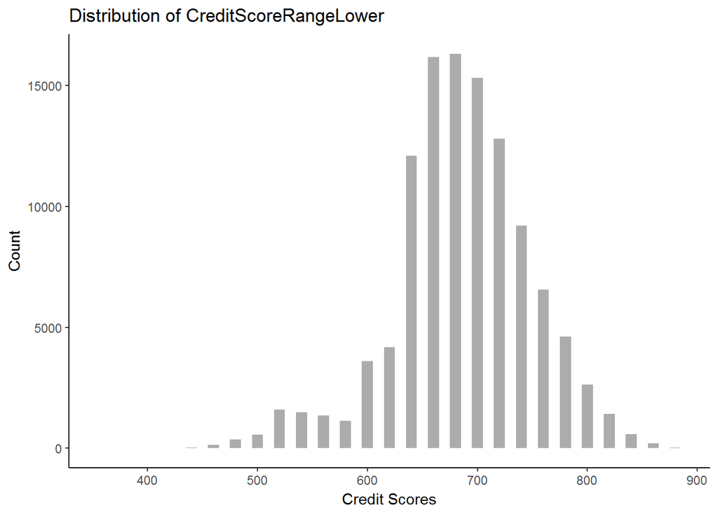

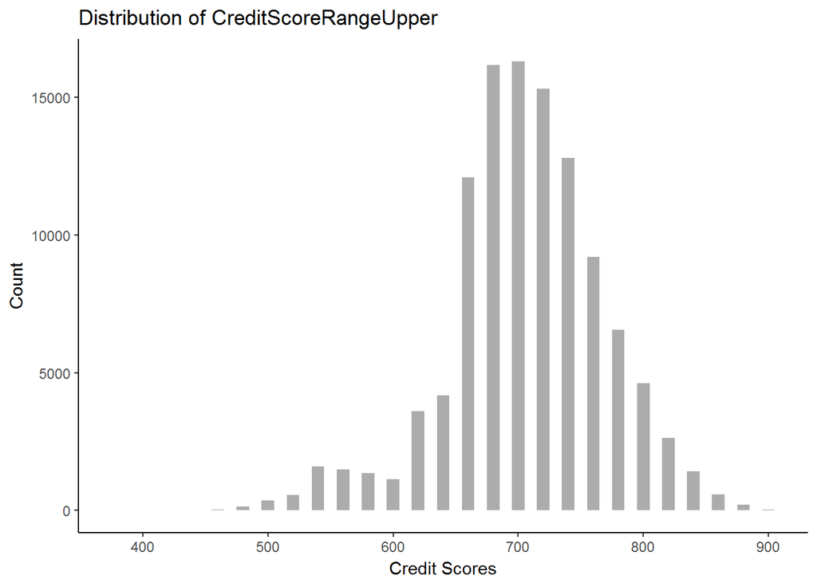

```
## [1] "Credit Range Lower summary"
```

```
##  CreditScoreRangeLower
##  Min.   :360.0
##  1st Qu.:660.0
##  Median :680.0
##  Mean   :686.3
##  3rd Qu.:720.0
##  Max.   :880.0
```

```
## [1] "Credit Range Upper summary"
```

```
##  CreditScoreRangeUpper
##  Min.   :379.0
##  1st Qu.:679.0
##  Median :699.0
##  Mean   :705.3
##  3rd Qu.:739.0
##  Max.   :899.0
```

Upper and lower credit score ranges are normally distributed.

Let’s take a look at pre-2009 credit data: CreditGrade

## Credit Grades Frequency Table

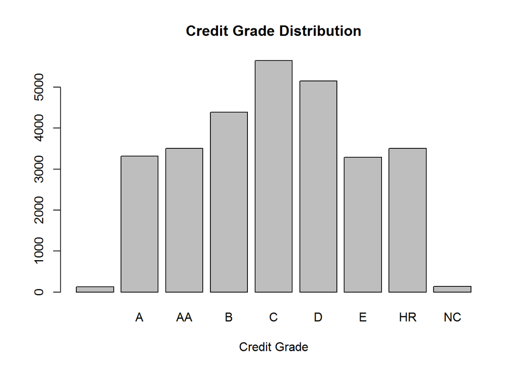

For listings entered prior to July 2009, Credit Grade was assigned. The most frequent credit grade is C.

## Prosper Ratings Distribution and summary

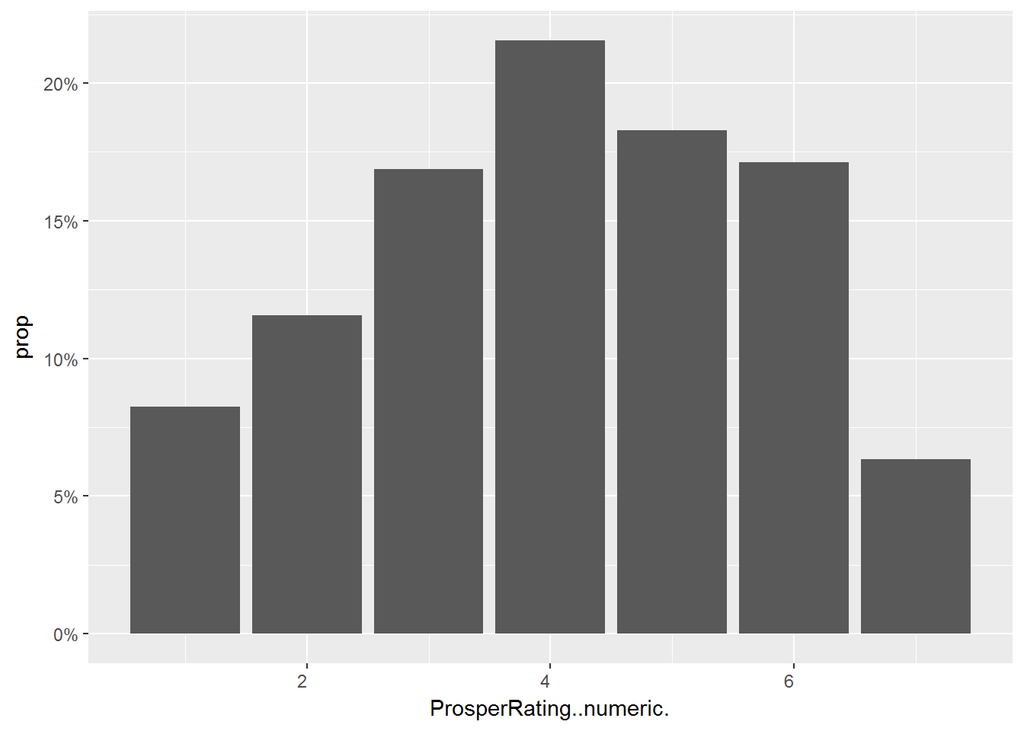

```
##    Min. 1st Qu.  Median    Mean 3rd Qu.    Max.    NA's
##   1.000   3.000   4.000   4.069   5.000   7.000   29084
```

Let’s look at the most common loan term & loan type

## Univariate Bar Charts, other variables

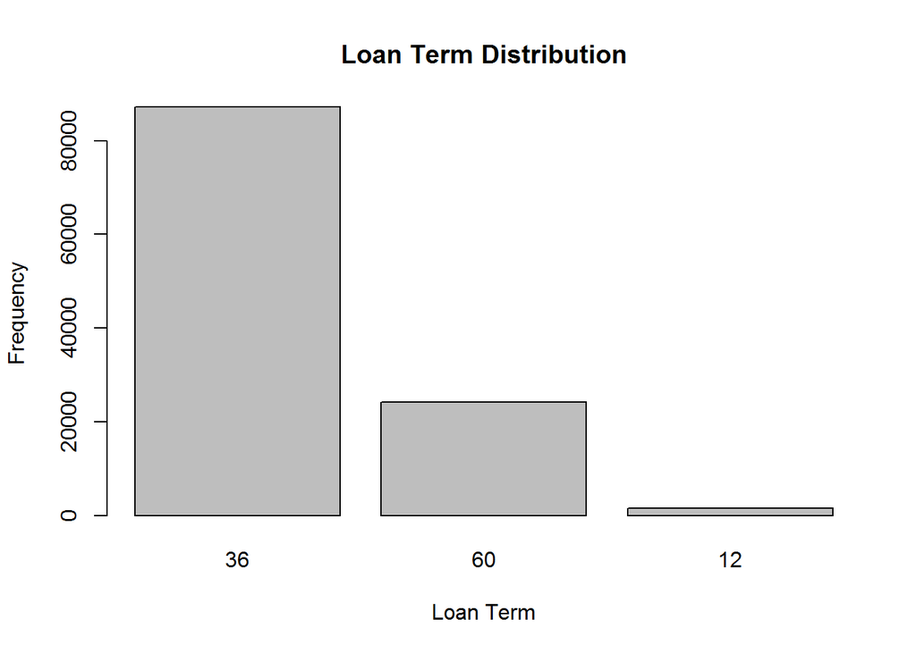

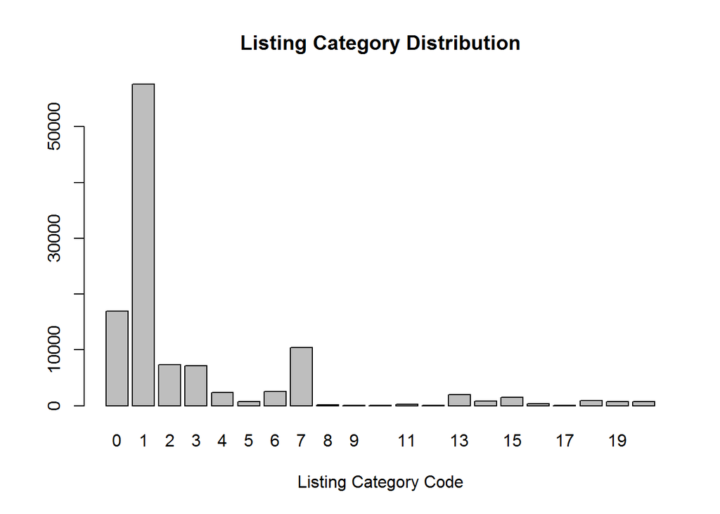

The most popular loan term is 36 months. Most frequent listing catergory is 1, which maps to Debt Consolidation in the data dictionary.

### Borrower State Frequency Table (proportions)

```
##
##           CA           TX           FL           NY           IL
## 0.1290750535 0.0600180426 0.0589655599 0.0589036492 0.0519342685
##                        GA           OH           MI           VA
## 0.0487768206 0.0440096935 0.0368280473 0.0315567898 0.0287531176
##           NC           NJ           WA           PA           MD
## 0.0271257496 0.0270815276 0.0267631295 0.0260909557 0.0247112306
##           MO           MN           MA           CO           IN
## 0.0229777298 0.0204128562 0.0196522385 0.0193603736 0.0182990466
##           AZ           WI           OR           TN           AL
## 0.0166451453 0.0161587038 0.0159729715 0.0152742646 0.0147524455
##           CT           SC           NV           KS           KY
## 0.0142660039 0.0098084305 0.0095342543 0.0093043001 0.0086144376
##           OK           LA           UT           AR           MS
## 0.0085436825 0.0083314170 0.0077211540 0.0075265774 0.0069251588
##           NE           ID           NH           NM           RI
## 0.0058726761 0.0052093468 0.0048290379 0.0041480197 0.0038207772
##           HI           WV           DC           MT           DE
## 0.0035996675 0.0034139352 0.0033520245 0.0029009605 0.0026444731
##           VT           AK           IA           SD           WY
## 0.0018131003 0.0017600340 0.0016450569 0.0016362125 0.0013266588
##           ME           ND
## 0.0008932836 0.0004599084
```

13% of borrowers are from CA.

## Original Loan Amounts Summary, Standard Deviation, and distribution plot

```
##    Min. 1st Qu.  Median    Mean 3rd Qu.    Max.
##    1000    4000    6300    8315   12000   35000
```

```
## [1] 6237.008
```

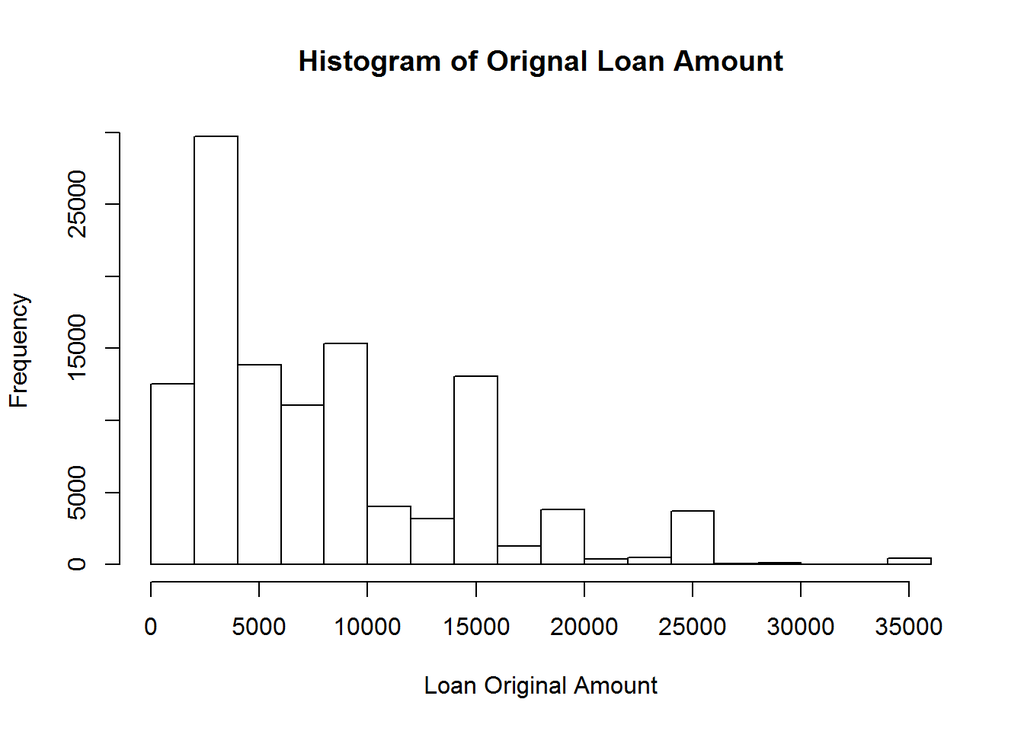

## Binning Borrower Rates & barplots

```
##    Min. 1st Qu.  Median    Mean 3rd Qu.    Max.
##  0.0000  0.1340  0.1840  0.1929  0.2506  0.4975
```

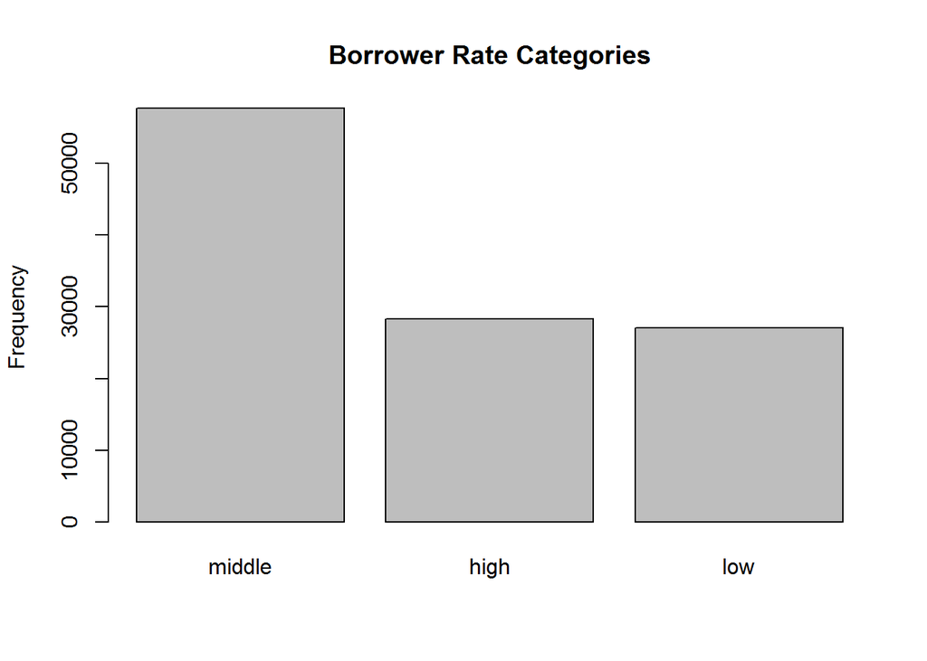

I binned borrower rates into 3 different cateogories: low, medium, high. Most borrowers have middle interest rates.

## Income

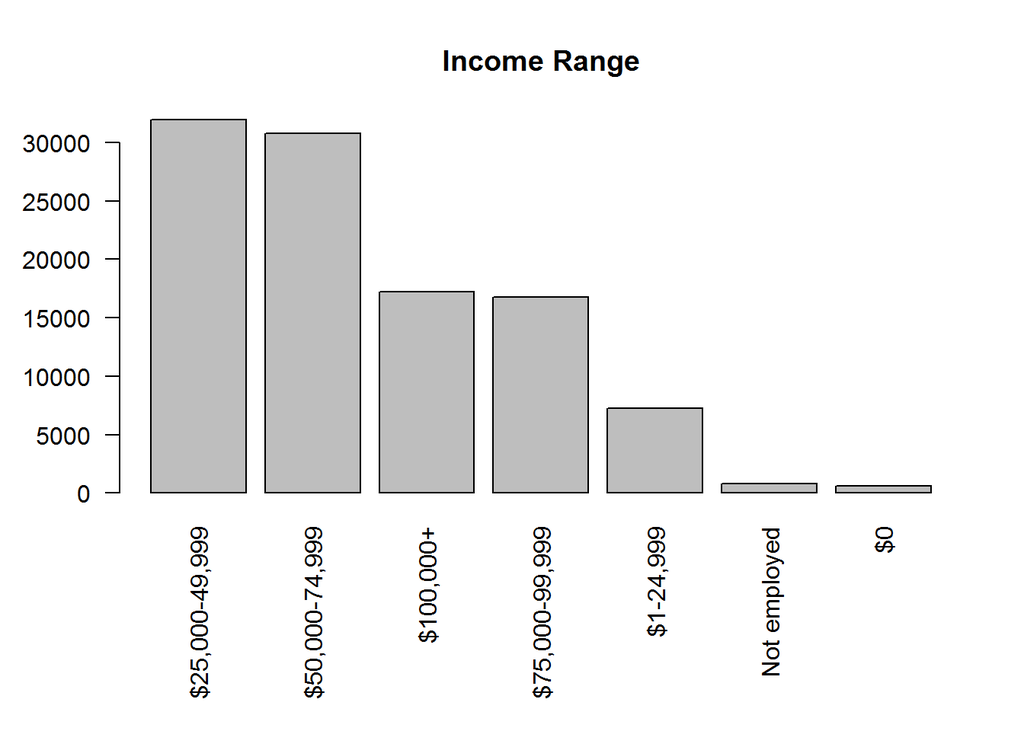

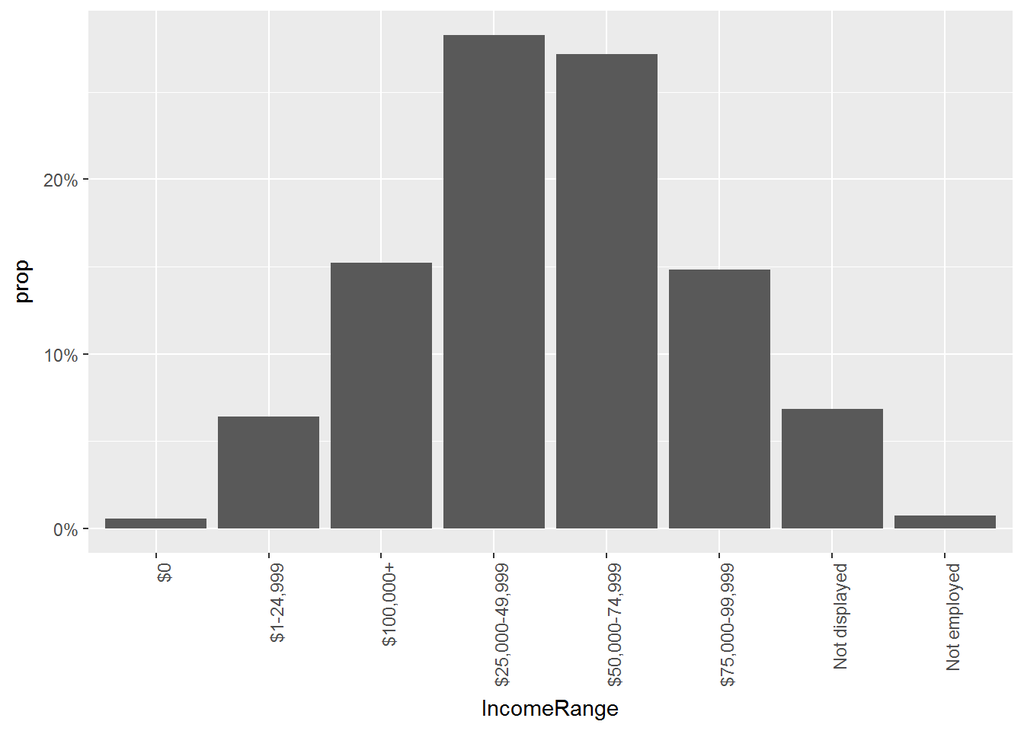

Around 50-60% of all customers who take out loans have an income range of $25,000-78,000.

## Borrower Rate Distribution & Summary

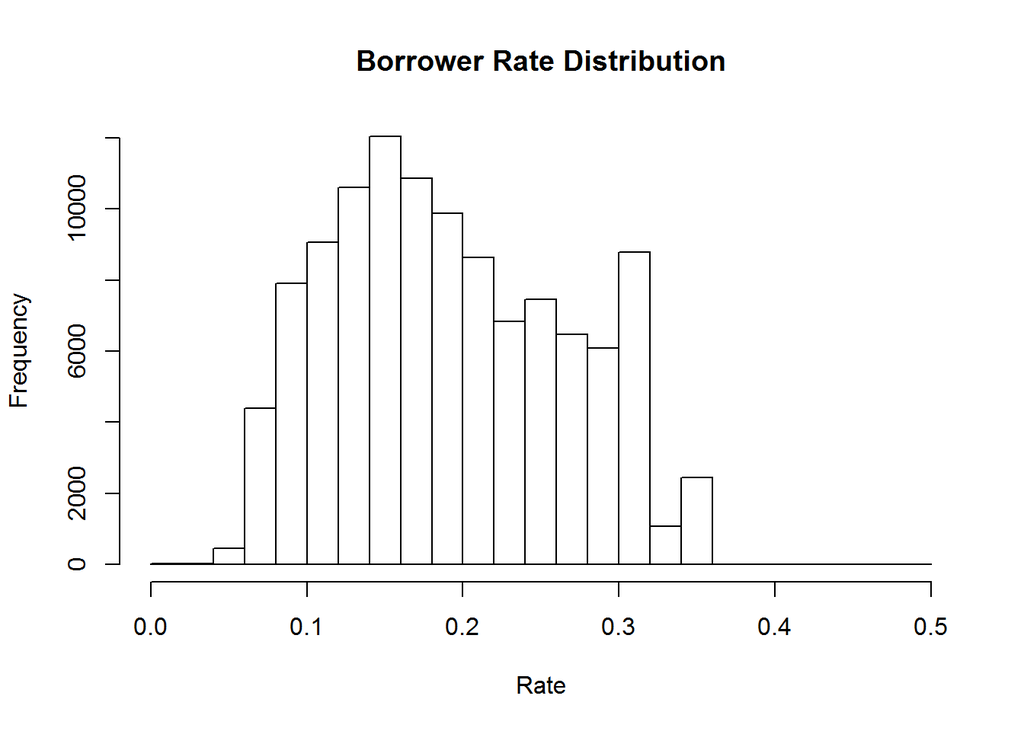

```
## [1] "Borrower Rate Summary"
```

```
##    Min. 1st Qu.  Median    Mean 3rd Qu.    Max.
##  0.0000  0.1340  0.1840  0.1929  0.2506  0.4975
```

Borrower rate is multimodal with median rate of 0.184 and average of 0.1929.

## Investors distribution, standard deviation and summary

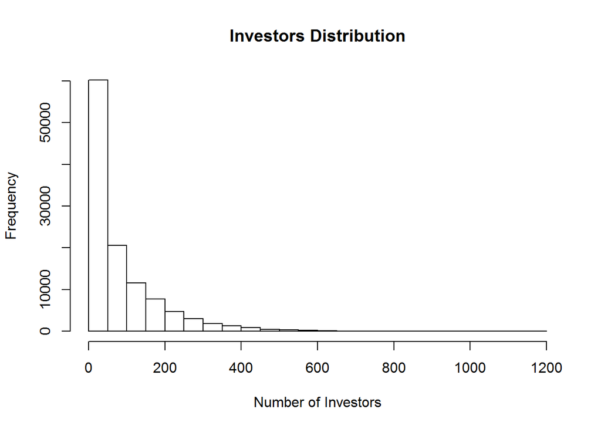

```
##    Min. 1st Qu.  Median    Mean 3rd Qu.    Max.
##    1.00    2.00   44.00   80.88  116.00 1189.00
```

```
## Standard deviation: 103.3403
```

Investors is right skewed with most loans have a smaller number of investors. The mean number of investors is 80 +/- 103 which indicates a wide spread of data. I will transform this to normal distribution so I can further analyze against other variables.

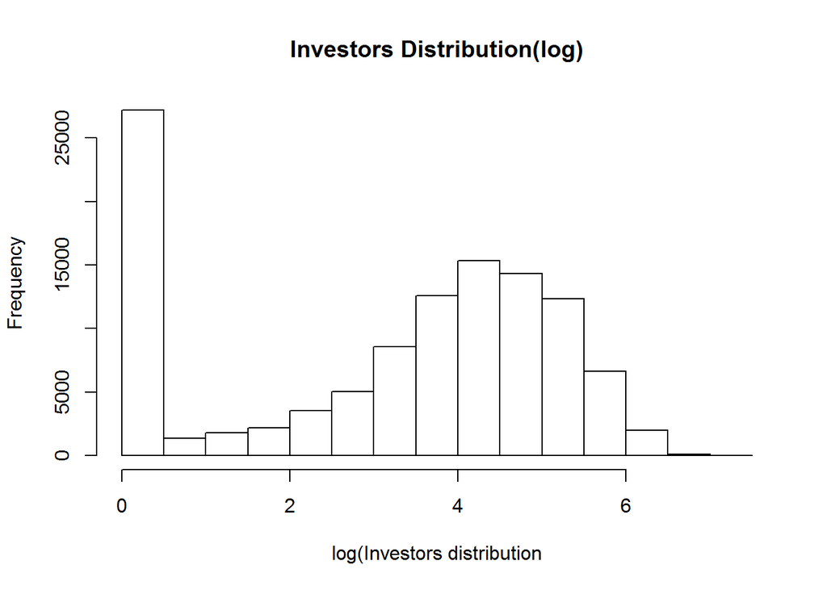

# Univariate Analysis

### What is the structure of your dataset?

The Prosper Loan dataset has 113937 observations and 81 variables. This dataset contains both catergorical and quantitative variables. This dataset contains consumer credit/debt information and loan specific information. The unique identifier of this dataset is the listing key/listing number. I created 2 separate dataframes for this dataset because the variables used in these 2 different time frames are vastly different. I created a dataframe for loans prior to July 2009 and those after.

Things of interest

### What is/are the main feature(s) of interest in your dataset?

The main features of interest for me is the relationship between a few different variables and a borrower’s interest rate. I’d also like to see which clients tend to end up deliquent.  
### What other features in the dataset do you think will help support your  
investigation into your feature(s) of interest?

The number of investors and income range of borrowers may help support my analysis

### Did you create any new variables from existing variables in the dataset?

I create a new variable called rate_category which puts different ranges of borrower rates into 3 different bins: high, medium, low. I also transformed some variables that were right skewed by taking the log of it to help normalize the distribution.

### Of the features you investigated, were there any unusual distributions? Did you perform any operations on the data to tidy, adjust, or change the form of the data? If so, why did you do this?

Yes, I found a few unusual distributions with credit scores. The minimum values were too low at 0 and 19. I found that these values were entered on loans prior to July 2009 where they used a different variable to assess credit worthiness.

# Bivariate Plots Section

### Rate category plotted against categorical variables

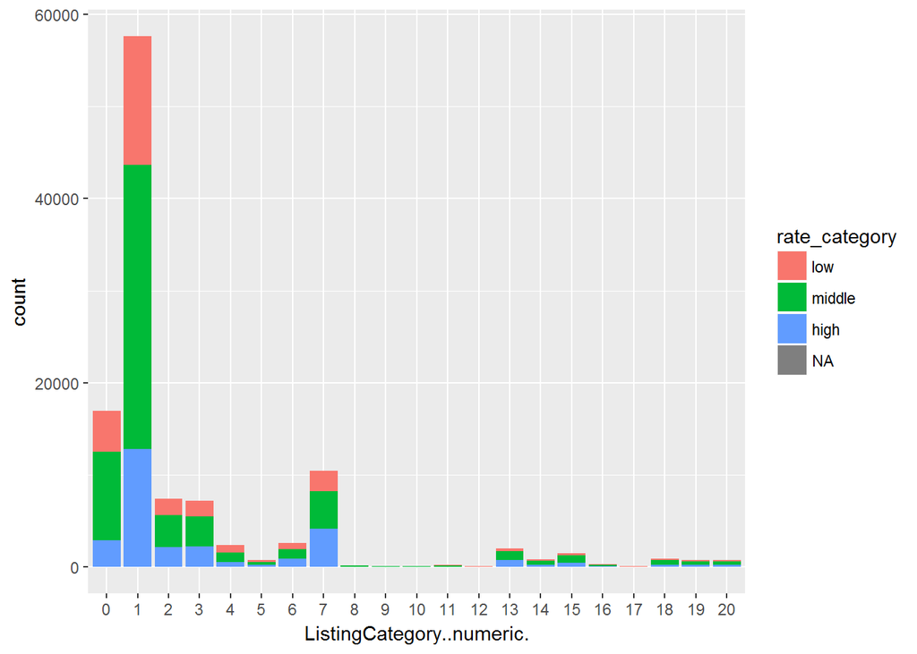

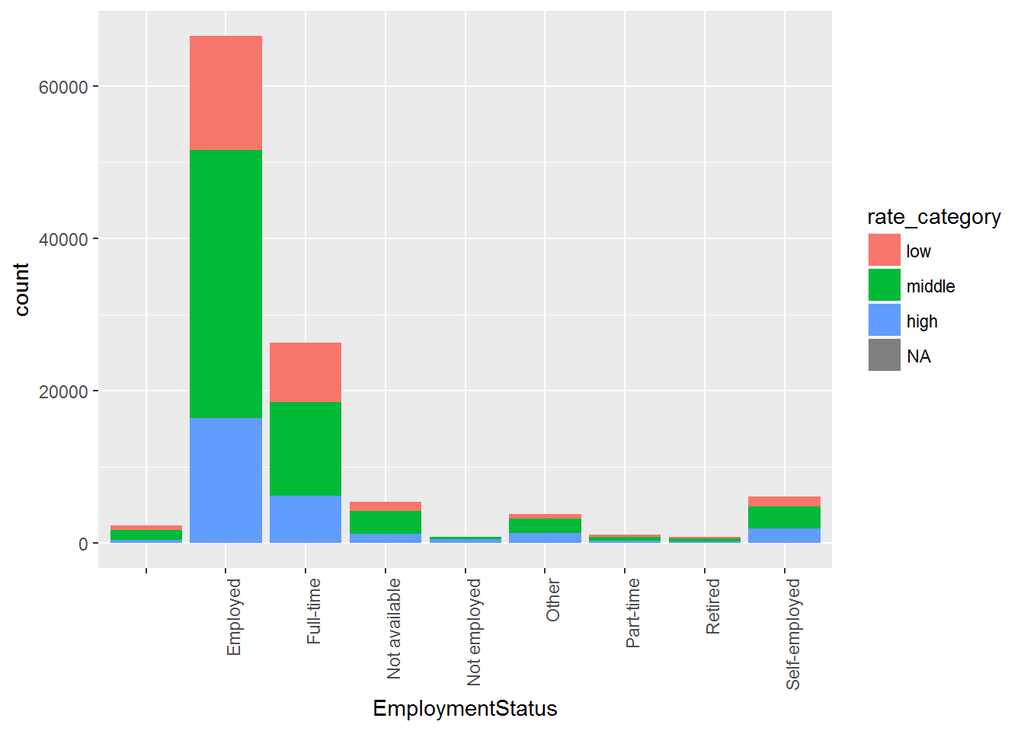

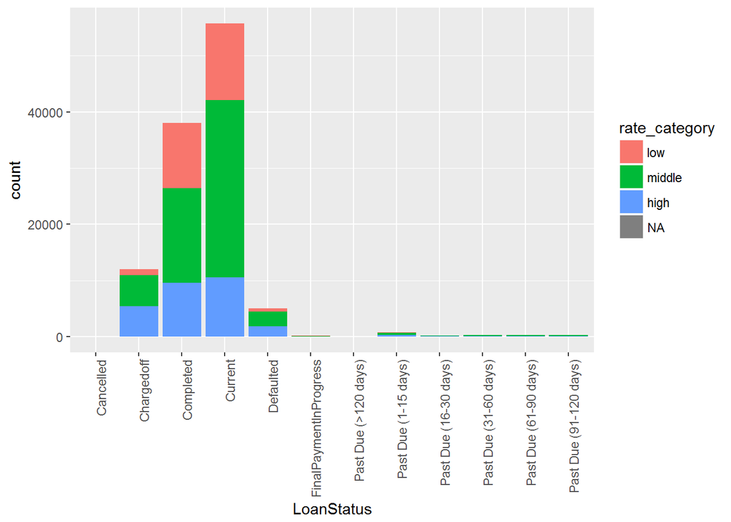

Here are some bar charts looking at rate category and other categorical variables. Most borrowers are employed. I wanted examine the relationship between different borrower rate cateogories with loan status, employment status, and listing type. There seems to be a somewhat equal proportion of interest rate categories for each listing type, with middle interest rates having a slightly higher proportion. We can see the same pattern for the other variables.

## Contingency Tables

```
##                                low     middle       high
##
## Cancelled               0.20000000 0.80000000 0.00000000
## Chargedoff              0.08655771 0.46280854 0.45063376
## Completed               0.30624901 0.44281810 0.25093288
## Current                 0.24453616 0.56637359 0.18909026
## Defaulted               0.10404624 0.52641021 0.36954355
## FinalPaymentInProgress  0.26108374 0.42364532 0.31527094
## Past Due (>120 days)    0.00000000 0.50000000 0.50000000
## Past Due (1-15 days)    0.06750000 0.53000000 0.40250000
## Past Due (16-30 days)   0.05660377 0.50943396 0.43396226
## Past Due (31-60 days)   0.08310249 0.46260388 0.45429363
## Past Due (61-90 days)   0.05466238 0.49196141 0.45337621
## Past Due (91-120 days)  0.05921053 0.45723684 0.48355263
```

```
##                           low middle  high
##
## Cancelled                   1      4     0
## Chargedoff               1038   5550  5404
## Completed               11654  16851  9549
## Current                 13628  31564 10538
## Defaulted                 522   2641  1854
## FinalPaymentInProgress     53     86    64
## Past Due (>120 days)        0      8     8
## Past Due (1-15 days)       54    424   322
## Past Due (16-30 days)      15    135   115
## Past Due (31-60 days)      30    167   164
## Past Due (61-90 days)      17    153   141
## Past Due (91-120 days)     18    139   147
```

## Chi-squared indepedence test

```
##
##  Pearson's Chi-squared test
##
## data:  mytab2
## X-squared = 6619.3, df = 22, p-value < 2.2e-16
```

Chi-squared indepedence test results indicate that these variables are not independent.

### Chi-squared residuals table

```
##                             low  middle    high
##
## Cancelled                -0.179   0.906  -1.119
## Chargedoff              -34.159  -7.317  43.829
## Completed                26.797 -18.492   0.221
## Current                   2.634  18.443 -28.910
## Defaulted               -19.561   1.572  16.870
## FinalPaymentInProgress    0.641  -1.733   1.848
## Past Due (>120 days)     -1.956  -0.059   1.996
## Past Due (1-15 days)     -9.925   0.770   8.600
## Past Due (16-30 days)    -6.075  -0.025   5.973
## Past Due (31-60 days)    -6.061  -1.275   7.744
## Past Due (61-90 days)    -6.651  -0.459   7.155
## Past Due (91-120 days)   -6.414  -1.301   8.125
```

### Chi-squared results visualized

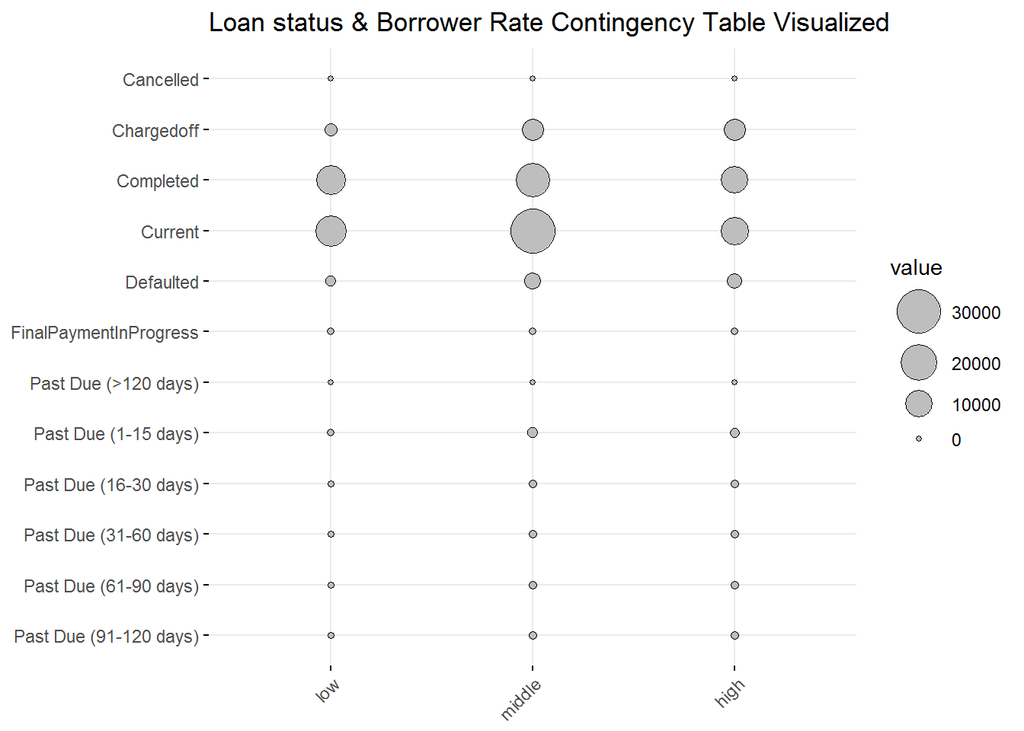

When looking at loan status and rate category, we can see that borrowers with lower rates are less likely to default and charge off a loan. It is evident from the chi squared test that there is an positive association between high rates and charge offs.

### Debt to Income ratio

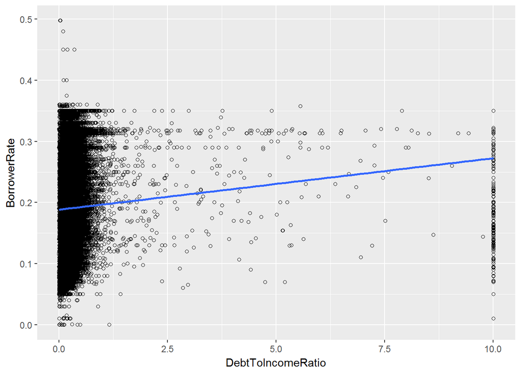

```
## [1] "DebtToIncomeRatio Summary"
```

```
##    Min. 1st Qu.  Median    Mean 3rd Qu.    Max.    NA's
##   0.000   0.140   0.220   0.276   0.320  10.010    8472
```

Doesn’t seem to be a clear relationship here. Higher debt to income ratio does not translate into higher rates.

### Other boxplots

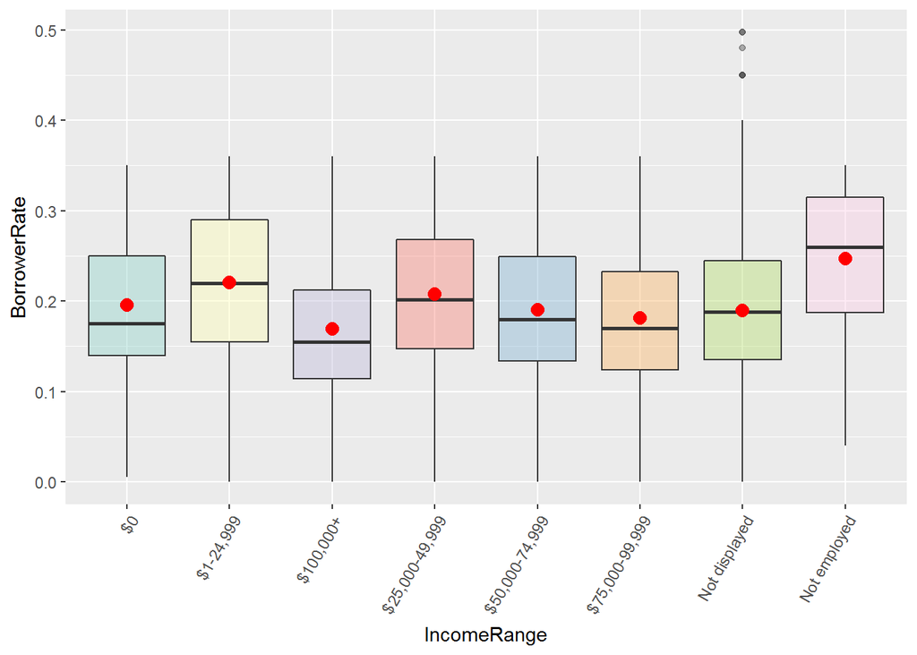

Figure above shows the distribution of borrower rates by income range. Those with Income Range reported as “Not Employed” seem to have the highest median and mean rate. Borrowers with higher income ranges have lower mean and median values. There are some outliers for borrowers whose income range is categorized as Not displayed.

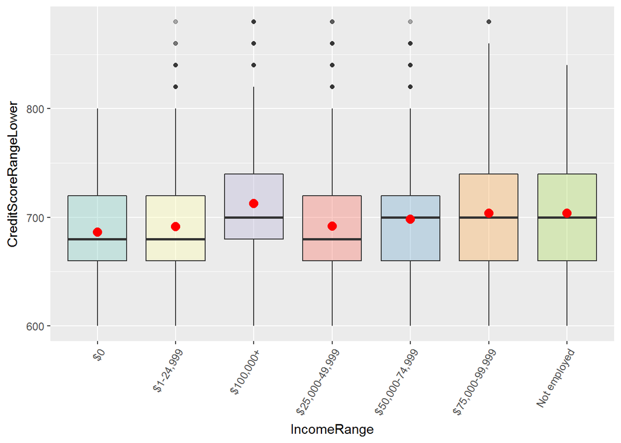

Borrowers with lower incomes have lower median and average credit scores. Borrowers with income 100k+ have highest credit scores.

#### Mean, Median and Standard Deviation of creditScors by Income Range

```
##      IncomeRange CreditScoreRangeLower
## 1             $0              686.2222
## 2      $1-24,999              691.1621
## 3      $100,000+              712.4230
## 4 $25,000-49,999              691.8731
## 5 $50,000-74,999              698.0897
## 6 $75,000-99,999              703.5483
## 7   Not employed              703.5131
```

```
##      IncomeRange CreditScoreRangeLower
## 1             $0                   680
## 2      $1-24,999                   680
## 3      $100,000+                   700
## 4 $25,000-49,999                   680
## 5 $50,000-74,999                   700
## 6 $75,000-99,999                   700
## 7   Not employed                   700
```

```
##      IncomeRange CreditScoreRangeLower
## 1             $0              47.25602
## 2      $1-24,999              43.72251
## 3      $100,000+              49.70882
## 4 $25,000-49,999              44.29891
## 5 $50,000-74,999              46.35005
## 6 $75,000-99,999              48.35976
## 7   Not employed              46.21458
```

There does seem to be some correlation between income and credit scores, so I will run a significance test to verify.

Null h: There is no differece between the means of each income group Alt hyp: There is a difference between the means of each income group

```
##                         Df    Sum Sq Mean Sq F value Pr(>F)
## post2009$IncomeRange     6   4531322  755220   347.6 <2e-16 ***
## Residuals            83975 182450846    2173
## ---
## Signif. codes:  0 '***' 0.001 '**' 0.01 '*' 0.05 '.' 0.1 ' ' 1
```

### More boxplot fun

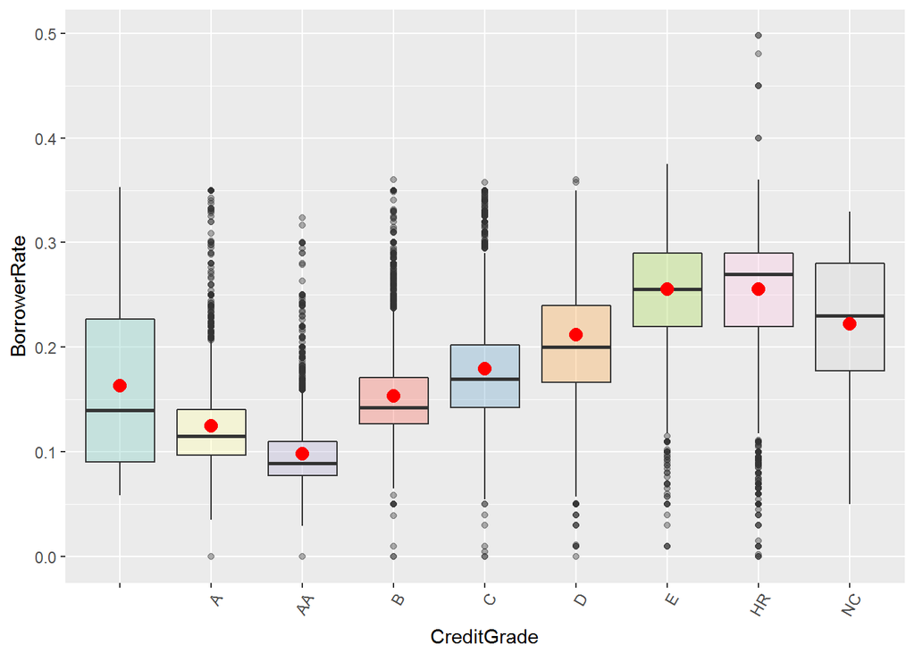

Borrowers with AA credit grade have Lowest rates and highest rates have E and HR grades.

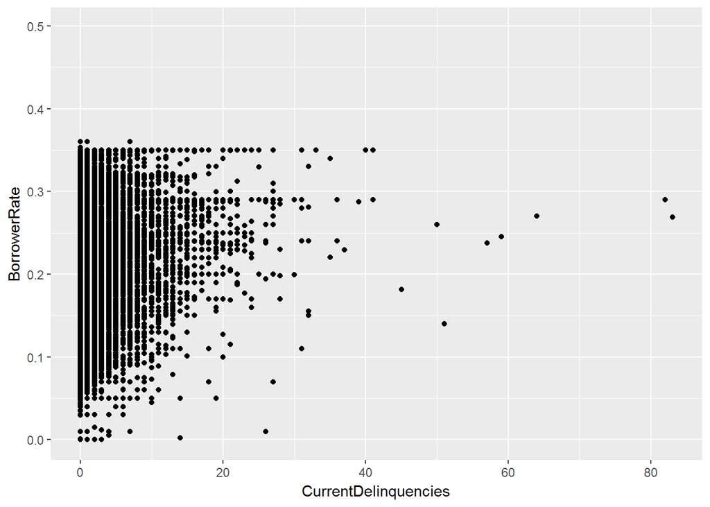

I wanted to see if there was any correlation between rates and number of current delinquencies. Most borrowers have under 20.

## Correlation Matrix

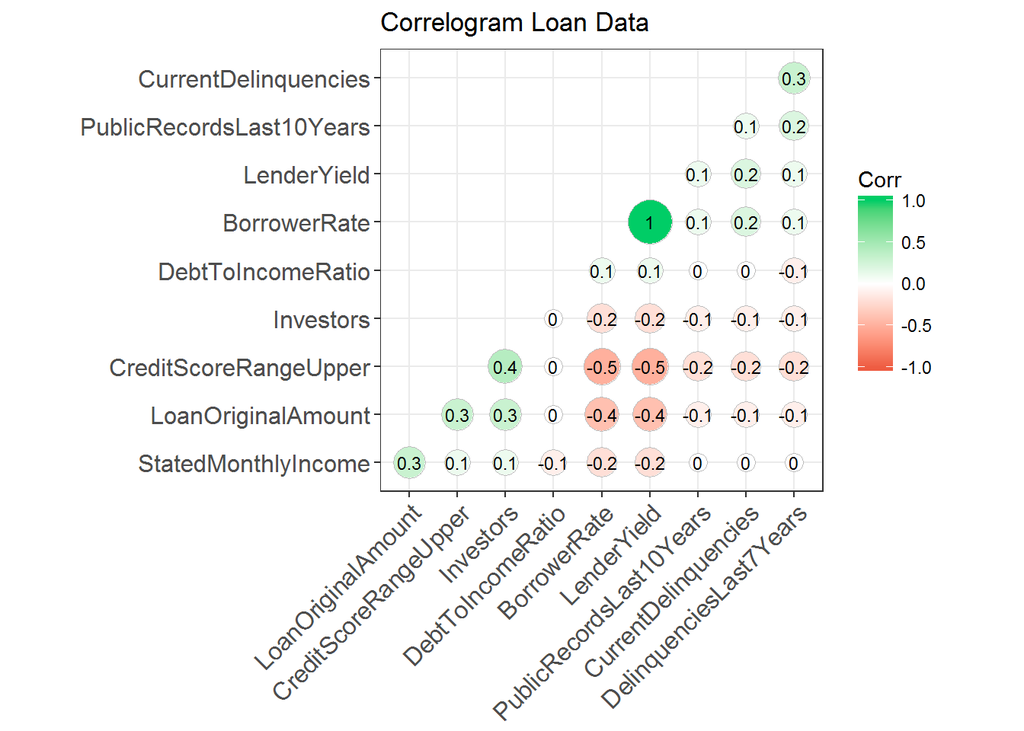

I created a correlation matrix and plotted it to quickly see the correlation between multiple variables. The strongest correlation is between borrower rate and lender yield.

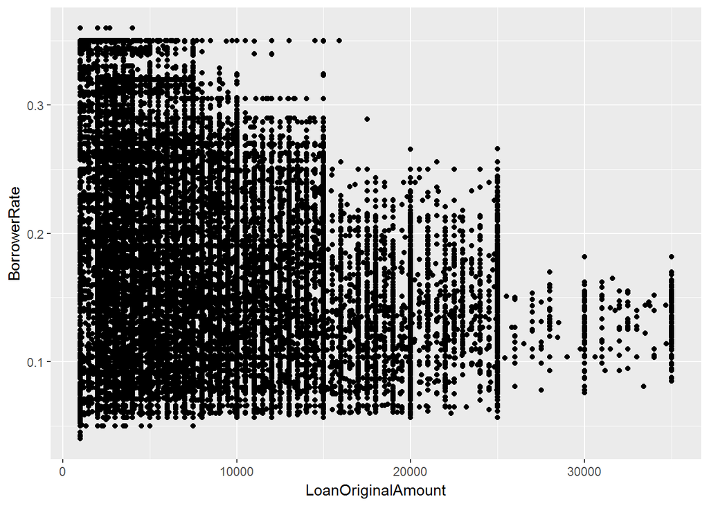

Scatter plot of original loan amount and borrower rate. Looks like there is somewhat of a negative correlation here.

## Linear Regression BorrowerRate ~ LoanOriginal Amount

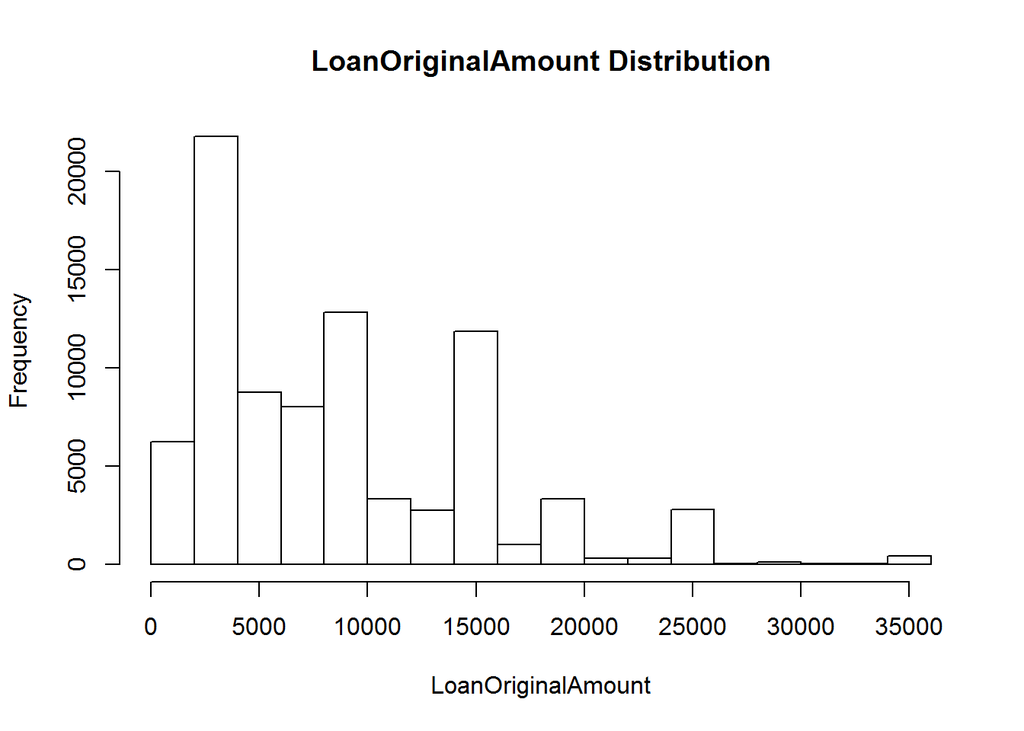

Need to take log of LoanOriginalAmount before running regression

#### Model build

```
##
## Call:
## lm(formula = BorrowerRate ~ LoanOriginalAmount, data = post2009)
##
## Residuals:
##       Min        1Q    Median        3Q       Max
## -0.238325 -0.049665  0.002354  0.054827  0.187825
##
## Coefficients:
##                      Estimate Std. Error t value Pr(>|t|)
## (Intercept)         0.5683626  0.0028327   200.6   <2e-16 ***
## LoanOriginalAmount -0.0419872  0.0003186  -131.8   <2e-16 ***
## ---
## Signif. codes:  0 '***' 0.001 '**' 0.01 '*' 0.05 '.' 0.1 ' ' 1
##
## Residual standard error: 0.06804 on 83980 degrees of freedom
## Multiple R-squared:  0.1714, Adjusted R-squared:  0.1714
## F-statistic: 1.737e+04 on 1 and 83980 DF,  p-value: < 2.2e-16
```

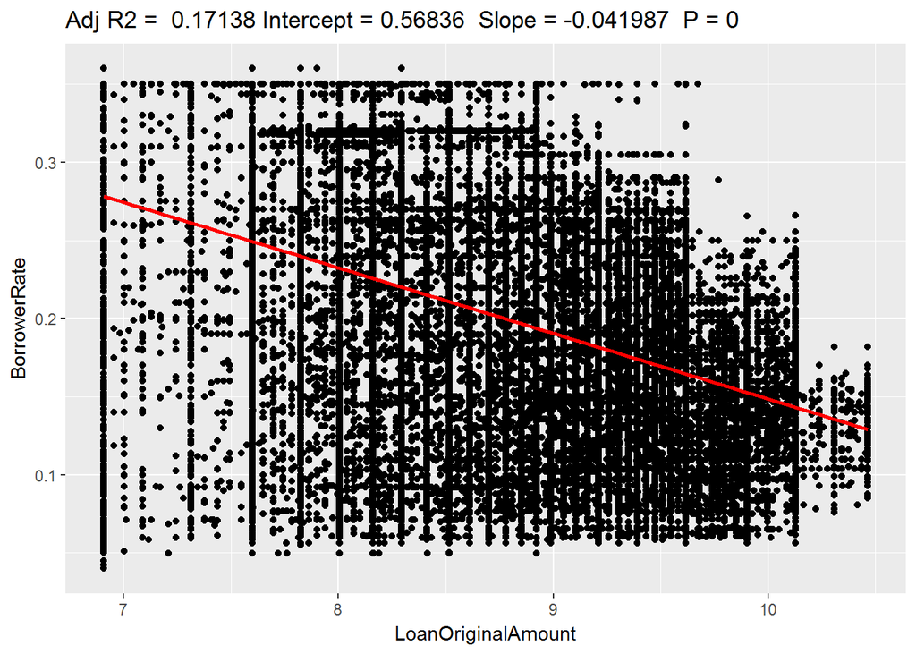

I performed linear regression to predict to the value of borrow rates using original loan amount. R-squared is pretty low so I will try another variable.

## Testing next set of variables, LenderYield ~ BorrowerRate

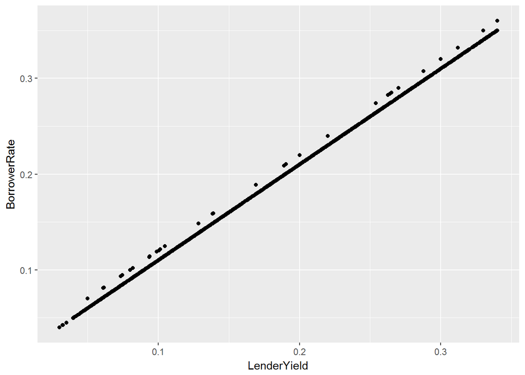

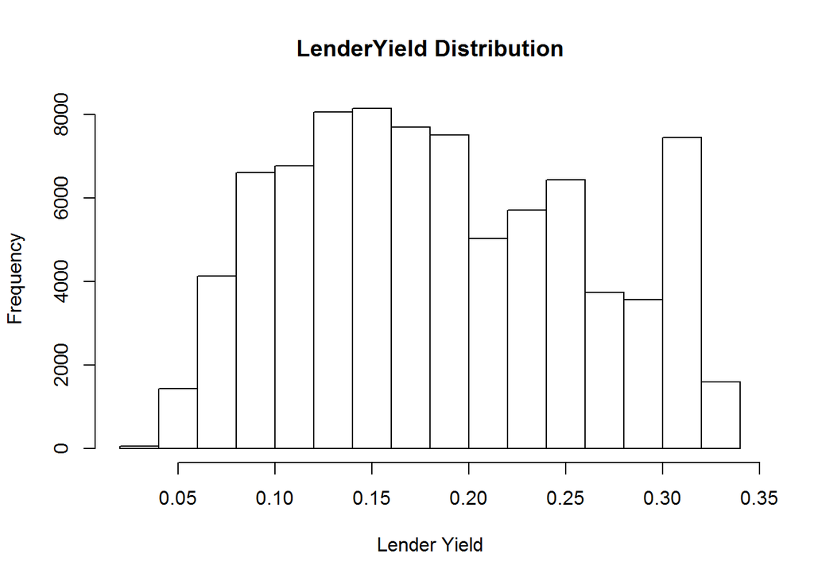

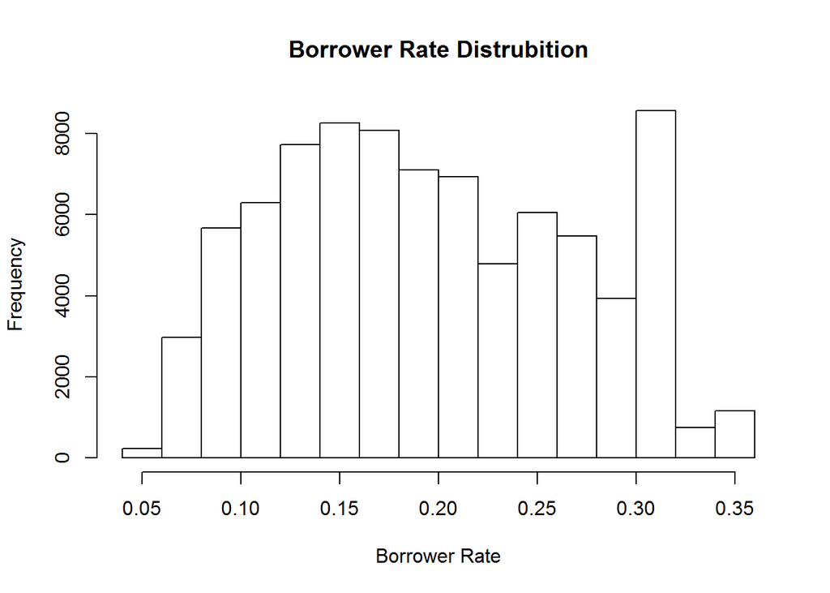

Checking these borrwer rate and lender yield normaility in the first two graph and strong positive correlation.

## Linear Regression Model #2 BorrowerRate ~ LenderYield

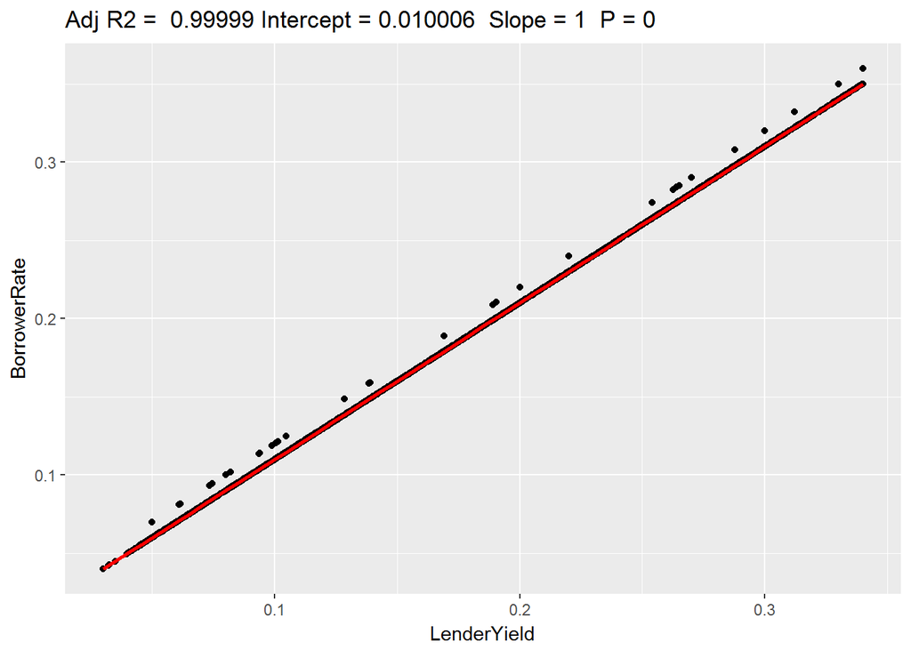

Very strong positive correlation between these two variables. It’s probably the result of the lender yield being calculated from the borrower rate.

# Bivariate Analysis

### Talk about some of the relationships you observed in this part of the investigation. How did the feature(s) of interest vary with other features in the dataset?

I mainly focused on what variables had an association with a borrower’s interest rate. I created a few contingency tables with different variables and found rate category and loan status to be the most interesting. I did a chi-squared indepedence test on these 2 variables and found that they are not independent. Rate does have an association with loan status. I found that there is statistically significant difference beteween the mean credit scores of between income range groups. The data suggests that higher income groups have higher average credit scores.

### Did you observe any interesting relationships between the other features (not the main feature(s) of interest)?

I thought it was interesting that there didn’t seem to be any relationship between debt to income ratio and interest rate. I would have assumed that this would have a big impact on borrower rate, but it does not.

# Multivariate Plots Section

## Scatter plots

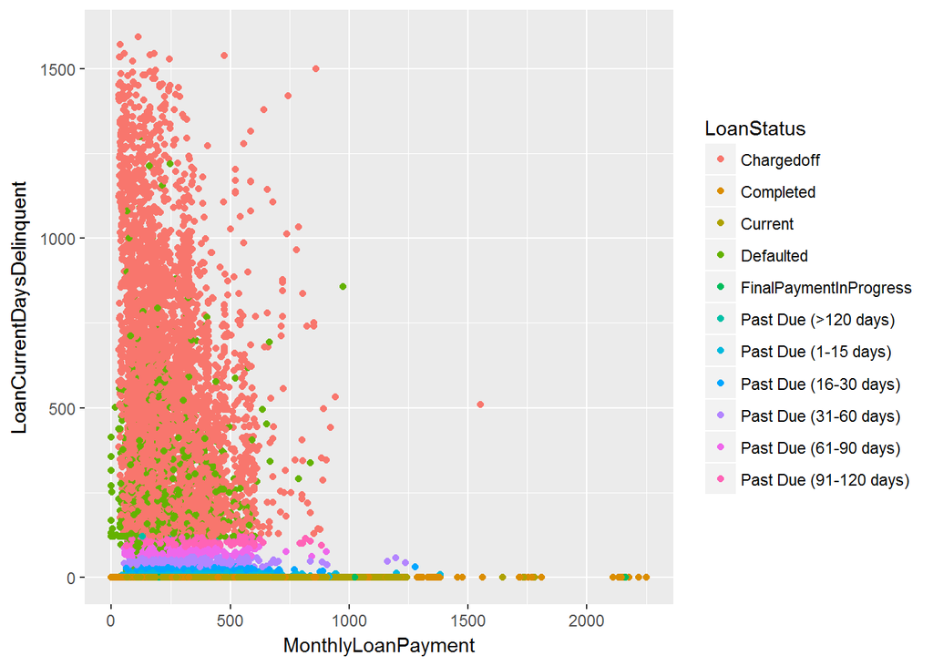

I wanted to see if there was any corrleation between the amount of monthly payments and loan deliquencies. It does not seem that there is. Perhaps, borrowers with weak credit profiles tend to have lower monthly payments because of the smaller loan amounts.